# Structure Learning for Bayesian Networks

HONG Kimmeng, KOH Tito, NOUV Ratanakmuny

2025-12-07

# 0. Installation of the Package

This document uses the package M2BayesNet, available on GitHub.

```r
if (!requireNamespace("M2BayesNet", quietly = TRUE)) {
  if (!requireNamespace("remotes", quietly = TRUE)) {
    install.packages("remotes")
  }
  remotes::install_github("rmnouv/M2BayesNet")
}
library(M2BayesNet)
```

# 1. Introduction

## 1.1 Problem Statement

Bayesian Networks (BNs) are probabilistic graphical models that represent conditional dependencies between variables using a **directed acyclic graph (DAG)**. Given $X = (X_1, \ldots, X_p)$, the joint distribution factorizes as:

$$P(X_1, \ldots, X_p) = \prod_{j=1}^p P(X_j \mid \text{Pa}(X_j)),$$

where $\text{Pa}(X_j)$ denotes the parents of variable $X_j$.

The objective of **structure learning** is to infer the DAG $\mathcal{G}$ that best explains the data. However:

- The number of DAGs grows **super-exponentially**:
  $$|\text{DAG}(p)| = 2^{\Theta(p^2)},$$
- The optimization problem is **NP-hard**
- Even moderate (p) prohibits naive enumeration

This motivates the use of **score-based structure learning**, where a scoring function such as BIC evaluates candidate DAGs, and optimization algorithms search the DAG space.

## 1.2 Goal of the Project

This project implements the three methods required by the assignment:

1. **Naive exhaustive search**
2. **Branch & Bound**
3. **Heuristic optimization (Hill-Climbing and Tabu Search)**

and evaluates their theoretical and empirical performance using both **R and C++** implementations.

## 1.3 Choice of the Score Function

In this project, we adopt the Bayesian Information Criterion (BIC) as the unique scoring function for evaluating Bayesian Network structures. BIC is particularly suitable for score-based structure learning because it offers a principled balance between model fit and model complexity, while remaining computationally tractable for both continuous and categorical variables.

### Mathematical Definition

For a Bayesian Network structure $\mathcal{G}$ with nodes $X_1, \ldots, X_p$, the BIC score is defined as:

$$\text{BIC}(\mathcal{G})
= \sum_{j=1}^{p}
\left[
\log L_j(\hat{\theta}_j)
- \frac{k_j}{2} \log N
\right],$$

where:

- $L_j(\hat{\theta}_j)$: maximized local likelihood of node $X_j$ given its parents $\mathrm{Pa}(X_j)$;
- $\hat{\theta}_j$: maximum likelihood estimates of parameters for node $X_j$;
- $k_j$: number of free parameters in the conditional distribution of $X_j$;
- $N$: sample size.

### Interpretation of BIC Components

- The log-likelihood term
  $$\log L_j(\hat{\theta}_j)$$
  measures how well the DAG explains the observed data.
- The penalty term
  $$\frac{k_j}{2} \log N$$
  increases with both the number of parameters and the sample size, discouraging overly complex parent sets.

### Reasons for Choosing BIC

BIC is selected for four fundamental reasons:

#### 1. Decomposability Across Nodes

BIC can be rewritten as a sum of local contributions:
$$\text{BIC} = \sum_{j=1}^p \text{BIC}(X_j \mid \mathrm{Pa}(X_j)).$$

This property is essential because:

- local scores depend only on parent sets,
- edge modifications require only local recomputation,
- heuristic search becomes efficient,
- Branch & Bound uses partial scores to prune subtrees.

Decomposability is a prerequisite for scalable structure learning, and BIC satisfies it naturally.

#### 2. Built-in Complexity Penalty

The BIC penalty term increases with model size. This discourages dense graphs, thereby producing:

- sparser structures,
- better generalization,
- resilience against overfitting.

Such sparsity aligns with the typical interpretation goals of Bayesian Networks.

#### 3. Statistical Consistency

Under mild regularity conditions, BIC is consistent:

$$\lim_{N \to \infty}
P\left(\widehat{\mathcal{G}}_{\text{BIC}} =
\mathcal{G}_{\text{true}}\right) = 1.$$

This theoretical guarantee supports using BIC in both exploratory and confirmatory learning tasks.

#### 4. Computational Efficiency

BIC requires only the MLE, not Bayesian marginalization or sampling. As a result:

- Gaussian and multinomial likelihoods admit closed-form solutions,
- evaluation is fast in both R and C++ (especially via BLAS/LAPACK in RcppArmadillo),
- BIC is suitable for repeated evaluation inside search algorithms.

Because our package evaluates the score thousands of times during a heuristic search, this efficiency is essential.

## 1.4 Choice of Gaussian and Multinomial Distributions

To support a broad range of datasets and ensure compatibility with BIC, our package implements two conditional models:

1. Gaussian distributions for continuous variables;
2. Multinomial distributions for categorical variables.

This choice reflects both statistical coherence and practical usability: many real datasets include exclusively numeric variables (e.g., Iris), while others are naturally categorical (e.g., Titanic, Asia). Supporting both families allows the package to be applied directly to standard benchmark datasets.

### 1.4.1 Gaussian Conditional Models

Gaussian Bayesian Networks assume that each continuous variable is a linear regression of its parents:

$$X_j \mid \mathrm{Pa}(X_j)
\sim
\mathcal{N}\left(
\beta_{0j} + \beta_{\mathrm{Pa}(j)}^\top X_{\mathrm{Pa}(j)},
\ \sigma_j^2
\right).$$

#### Parameter Estimation

Given $N$ samples, the MLEs are:

$$\hat{\beta}
= (X^\top X)^{-1} X^\top y,
\qquad
\hat{\sigma}^2 = \frac{1}{N} \|y - X\hat{\beta}\|^2.$$

These closed-form solutions are computationally efficient and take advantage of optimized numerical linear algebra when implemented in C++.

#### Local BIC Score for Gaussian Nodes

The local likelihood is:

$$\log L_j =
- \frac{N}{2}
\big(1 + \log(2\pi \hat{\sigma}_j^2)\big),$$

and the number of parameters is:

$$k_j = |\mathrm{Pa}(X_j)| + 2,$$

corresponding to regression coefficients, intercept, and variance.

#### Reasons for Choosing Gaussian Models

- Many benchmark datasets for structure learning (e.g., iris) contain continuous variables.
- The Gaussian assumption yields closed-form MLE, simplifying BIC computation.
- Gaussian models are broadly used in textbook Bayesian Networks, enabling straightforward comparison.
- The Gaussian model provides a clean, interpretable regression structure, facilitating pedagogical illustration.

### 1.4.2 Multinomial Conditional Models

For discrete datasets, each node $X_j$ takes one of $r_j$ possible states. Its conditional distribution given a parent configuration $k$ is modeled as:

$$P(X_j = s \mid \mathrm{Pa}(X_j) = k) = \theta_{jsk},
\qquad
\sum_{s=1}^{r_j} \theta_{jsk} = 1.$$

#### MLE Based on Contingency Tables

Given counts $N_{jsk}$, the MLE is:

$$\hat{\theta}_{jsk}
= \frac{N_{jsk}}{\sum_{s'} N_{js'k}}.$$

The log-likelihood can be expressed as a sum over parent configurations:

$$\log L_j =
\sum_{k} \sum_{s=1}^{r_j}
N_{jsk} \log \hat{\theta}_{jsk},$$

and the number of free parameters is:

$$k_j = (r_j - 1) q_j,$$

where $q_j$ is the number of distinct parent configurations.

#### Reasons for Choosing Multinomial Models

- Suitable for datasets consisting of categorical variables, such as Titanic or Asia.
- The multinomial model induces a natural factorization into contingency tables.
- Likelihood and BIC computations are simple and fast, especially in C++.
- The model integrates smoothly into structure learning algorithms without requiring approximations.
- It aligns with classical discrete Bayesian Networks used in many pedagogical examples.

## 1.5 Search Space and Optimization Problem

The structure learning problem can be written as:

$$\mathcal{G}^* = \arg \max_{\mathcal{G} \in \text{DAG}(p)}
\text{BIC}(\mathcal{G}),$$

subject to:

$$\mathcal{G} \text{ is a directed acyclic graph.}$$

The size of the search space is enormous:

$$|\text{DAG}(p)| = 2^{\Theta(p^2)}.$$

Even for $p = 10$, the number of DAGs exceeds $4 \times 10^{18}$.

Therefore:

- exact algorithms (Naïve, B&B) scale poorly
- heuristic algorithms are required for real data
- efficient C++ implementation is necessary to meet assignment requirements for complexity analysis

This motivates the structure of the project:

- Exact exploration (Naïve, Branch & Bound)
- Local greedy optimization (Hill-Climbing)
- Metaheuristic search (Tabu)
- R vs. C++ comparison for performance and complexity

# 2. The Dataset

In this project, we evaluate the three structure learning algorithms using two datasets: Boston Housing for continuous variables and Titanic for categorical variables. These datasets are chosen solely to provide suitable inputs for the Gaussian and Multinomial BIC scores implemented in the M2BayesNet package. The focus of the report is the algorithms rather than the datasets themselves; therefore, only brief descriptions and preprocessing steps are provided.

## 2.1 Boston Housing Dataset (Gaussian, 5 Variables)

The Boston Housing dataset contains continuous measurements related to housing values and socioeconomic indicators. To keep the dimensionality manageable for all algorithms (including Naïve and Branch & Bound), we select five continuous variables from the dataset:

- `crim` – per capita crime rate
- `rm` – average number of rooms per dwelling
- `dis` – distance to employment centers
- `tax` – property tax rate
- `medv` – median value of owner-occupied homes

These variables are real-valued and therefore suitable for the Gaussian BIC scoring function.

```r
library(MASS)
data(Boston)

# Select 5 continuous variables
vars <- c("crim", "rm", "dis", "tax", "medv")
X_boston <- as.matrix(Boston[, vars])

dim(X_boston)
```

```
## [1] 506   5
```

This numeric matrix is used directly as the input to all Gaussian-based structure learning functions.

## 2.2 Titanic Dataset

The Titanic dataset records the survival outcomes of passengers along four categorical attributes: Class, Sex, Age, and Survived. Since each variable takes a finite number of states, this dataset is suitable for the Multinomial BIC score, which operates on discrete variables.

The dataset is provided as a contingency table, so we convert it into a row-expanded data frame of individual observations:

```r
data("Titanic")
titanic_tab <- as.data.frame(Titanic)
titanic_df <- titanic_tab[
  rep(seq_len(nrow(titanic_tab)), titanic_tab$Freq),
  1:4
]
dim(titanic_df)
```

```
## [1] 2201    4
```

The resulting data frame contains one row per passenger and is ready to be used with the multinomial-based algorithms.

# 3. Algorithms

## 3.1. Naïve Exhaustive Search

This algorithm performs naïve score-based structure learning for Bayesian Networks. It works by finding all possible directed acyclic graphs and evaluate each candidate structure using the Bayesian Information Criterion (BIC). In this case, we work on two different type of dataset: Gaussian (using linear regression and residual variance estimates) and Multinomial (using conditional contingency tables).

**Algorithm Description**

1. Generate all possible adjacency matrices for p nodes
2. Filter out matrices that are not acyclic and keep only DAGs
3. Compute each DAG’s global BIC by summing local BICs for all nodes
4. Update the best DAG if its score is higher
5. Return best_adj, best_score and time computation

#### `naive_bn_structure_learning`

**Input**

- `X`: Dataset (data frame or matrix of size $N \times p$).
  - Numeric for `distribution = "gaussian"`.
  - Categorical / factors (or coercible) for `distribution = "multinomial"`.
- `distribution`: `"gaussian"` or `"multinomial"`.

**Output**

A list containing:

- `best_adj` – Best DAG adjacency matrix ($p \times p$).
- `best_score` – BIC score of the best DAG.
- `time` – Time computation.

**Example of usage**

```r
res_naive <- naive_bn_structure_learning(X_boston, distribution = "gaussian")
```

```
## Generating all possible DAGs...
## 29281 acyclic DAGs generated.
## Execution time: 2.709248
```

```r
print(res_naive$best_score)
```

```
## [1] -8211.749
```

```r
print(set_adj_names(res_naive$best_adj, X_boston))
```

```
##      crim rm dis tax medv
## crim    0  0   0   0    0
## rm      0  0   0   0    0
## dis     0  0   0   0    0
## tax     1  0   1   0    0
## medv    1  1   0   1    0
```

```r
print(res_naive$time)
```

```
## Time difference of 2.709248 mins
```

```r
res_naive_multinomial <- naive_bn_structure_learning(titanic_df, "multinomial")
```

```
## Generating all possible DAGs...
## 543 acyclic DAGs generated.
## Execution time: 1.842426
```

```r
print(set_adj_names(res_naive_multinomial$best_adj, titanic_df))
```

```
##          Class Sex Age Survived
## Class        0   0   1        0
## Sex          1   0   0        1
## Age          0   0   0        0
## Survived     1   0   1        0
```

```r
print(res_naive_multinomial$time)
```

```
## Time difference of 1.842426 secs
```

## 3.2 Branch and Bound

Branch and Bound (BnB) is an exact score-based structure learning algorithm for Bayesian networks. Branch and Bound guarantees finding the globally optimal DAG under the chosen score (BIC), at the cost of potentially heavy computation. The approach searches over topological orders (or parent sets) while using admissible upper bounds to prune subtrees that cannot improve the current best solution.

**Algorithm Description**

1. **Precompute Local Scores:**  
   For each variable, compute the local BIC score for every possible parent subset (all subsets of the other variables).
2. **Initialize Search:**  
   Start with an empty graph, no nodes placed, and a global best score of $-\infty$.
3. **Recursive Search (DFS over Node Orderings):**
   - At each step, select a node to add to the current ordering.
   - Consider all allowed parent sets (subset of nodes already placed).
   - Compute the best local BIC score for that node given the allowed parents.
   - Update the current score and parent mask.
4. **Pruning Using Upper Bound:**
   - Compute the optimistic score: current score + sum of best possible scores for remaining nodes.
   - If this upper bound ≤ global best score, prune this branch and do not explore further.
5. **Update Global Best:**
   - If a complete ordering is reached and the score is higher than the global best, update the global best adjacency matrix and score.
6. **Termination:**
   - The search ends when all branches are either explored or pruned.
   - Return the DAG with the highest BIC score.

#### `branch_and_bound_bn` (R version)

**Inputs**

- `X`: Dataset (data frame or matrix of size $N \times p$).
  - Numeric for `distribution = "gaussian"`.
  - Categorical / factors (or coercible to factors) for `distribution = "multinomial"`.
- `distribution`: `"gaussian"` or `"multinomial"`.
- `...` (optional) additional arguments (e.g., user-provided `X_disc`, `n_levels` for multinomial or timeouts if implemented).

**Output**

A list containing:

- `best_adj` – adjacency matrix ($p \times p$) of the optimal DAG.
- `best_score` – global BIC score of the returned DAG.
- `time` – elapsed wall-clock time (seconds).
- `nodes_explored` – number of partial states/orders visited.
- `pruned` – number of pruned branches (by admissible bound).

**Example Usage**

```r
# Multinomial example (dataset as dataframe)
res_bnb <- branch_and_bound_bn(X_boston, distribution = "gaussian")
```

```
## Precomputing local scores for every node and parent subset (2^p masks each)...
```

```r
res_bnb$best_score
```

```
## [1] -8211.749
```

```r
res_bnb$best_adj <- set_adj_names(res_bnb$best_adj, X_boston)
res_bnb$best_adj
```

```
##      crim rm dis tax medv
## crim    0  0   0   1    0
## rm      0  0   0   0    1
## dis     0  0   0   0    0
## tax     0  0   1   0    0
## medv    1  0   0   1    0
```

#### `branch_and_bound_bn_cpp` (C++ version)

The C++ implementation of Branch and Bound is designed for **speed** and **exactness**, making it suitable for experiments where the R version would be too slow.  
This function evaluates all possible parent subsets and performs a depth-first search with pruning using an admissible upper bound based on the best possible local scores.

**Inputs**

- `X` : Dataset (data frame or matrix of size $N \times p$).
  - Numeric matrix (Gaussian case).
  - Or a `data.frame` of factors (Multinomial case).
  - If factors are supplied, the C++ wrapper automatically converts them to:
    - `X_disc`: integer matrix (`0,1,…,r-1`)
    - `n_levels`: number of levels for each variable.
- `distribution`: `"gaussian"` or `"multinomial"`, determining how local scores are computed.

**Outputs**

A list containing:

- `best_adj`: The adjacency matrix (`p × p`) of the *globally optimal DAG* found by the algorithm.
- `best_score` : The best (highest) BIC score among all DAGs.
- `time`: Total elapsed wall-clock time spent during the search.
- `nodes_explored` : Number of partial states / search nodes visited in the Branch and Bound routine.
- `pruned`: Number of branches removed using the admissible upper-bound heuristic.

These fields allow comparing the computational difficulty of different datasets or distributions.

**Purpose**

The C++ implementation offers substantial performance improvements:

- Precomputation of local scores for all `2^p` parent subsets (per node).
- Efficient enumeration of submasks for choosing optimal parent subsets.
- Significantly faster branching and pruning compared to R.
- Useful for:
  - Time-complexity experiments
  - Comparing heuristic vs. exact structure learning
  - Benchmarks on real and synthetic datasets

**Example Usage**

```r
# Suppose X_boston is a numeric matrix (Gaussian)
res_bnb_cpp <- branch_and_bound_bn_cpp(X_boston, distribution = "gaussian")
```

```
## Precomputing local scores for every node and parent subset (2^p masks each)...
```

```r
# Set variable names on adjacency matrix
res_bnb_cpp$best_adj <- set_adj_names(res_bnb_cpp$best_adj, X_boston)
res_bnb_cpp$best_score
```

```
## [1] -8211.749
```

```r
res_bnb_cpp$best_adj
```

```
##      crim rm dis tax medv
## crim    0  0   0   0    0
## rm      0  0   0   0    1
## dis     0  0   0   0    0
## tax     1  0   1   0    0
## medv    1  0   0   1    0
```

## 3.3 Heuristic Algorithms

Heuristic algorithms provide practical, scalable alternatives to exact structure learning methods such as Naïve Exhaustive Search and Branch and Bound. Since the number of possible Directed Acyclic Graphs (DAGs) grows super-exponentially with the number of variables, heuristics aim to efficiently explore the search space by applying local modifications to the graph and evaluating the BIC score of neighboring configurations.

The M2BayesNet package implements two heuristic algorithms:

- Hill Climbing (HC)
- Tabu Search

Both algorithms rely on a common set of operations:

- Add an edge
- Delete an edge
- Reverse an existing edge

All operations must preserve acyclicity. At each iteration, the algorithms compute the BIC score of each valid neighbor and choose the next structure based on their respective search strategies.

### 3.3.1 Hill Climbing

Hill Climbing is a greedy local search method that iteratively improves the structure by selecting the neighbor with the highest BIC score. It terminates when no neighboring graph offers an improvement.

**Algorithm Description**

1. Initialization: Start with an initial DAG (by default: an empty graph).
2. Neighborhood Generation: Generate all valid single-edge modifications that do not create cycles.
3. Scoring: Evaluate each neighbor using the BIC score:
   $$\text{BIC}(\mathcal{G}) = \sum_{j=1}^{p} \left[ \log L_j(\hat{\theta}_j)
   - \frac{k_j}{2} \log N \right].$$
4. Move Selection: Select the neighbor with the highest BIC increase.
5. Stopping Rule: If no modification improves the score, the algorithm stops at a local optimum.

#### `hill_climbing_bn` (R version)

**Inputs**

- `X`: Dataset (data frame or matrix of size $N \times p$).
  - Numeric for `distribution = "gaussian"`.
  - Categorical / factors (or coercible) for `distribution = "multinomial"`.
- `distribution`: `"gaussian"` or `"multinomial"`.
- `max_iter`: Maximum number of hill-climbing iterations.
- `verbose`: If `TRUE`, prints progress information.

**Output**

A list containing:

- `adj` – final adjacency matrix ($p \times p$) of the learned DAG.
- `score` – BIC score of the final DAG.
- `history` – numeric vector of BIC scores across iterations.
- `iterations` – number of iterations actually performed.
- `distribution` – distribution assumption used.

**Example Usage**

```r
res_hc <- hill_climbing_bn(X_boston, distribution = "gaussian",
                           max_iter = 100, verbose = TRUE)
```

```
## Hill-Climbing (R): initial score = -8622.731
## Hill-Climbing (R): iter 1 - move add 2 -> 5 - score = -8458.68
## Hill-Climbing (R): iter 2 - move add 1 -> 4 - score = -8356.815
## Hill-Climbing (R): iter 3 - move add 4 -> 3 - score = -8274.836
## Hill-Climbing (R): iter 4 - move add 5 -> 1 - score = -8236.599
## Hill-Climbing (R): iter 5 - move add 5 -> 4 - score = -8211.749
## Hill-Climbing (R): no improvement at iteration 6
```

```r
res_hc$adj
```

```
##      crim rm dis tax medv
## crim    0  0   0   1    0
## rm      0  0   0   0    1
## dis     0  0   0   0    0
## tax     0  0   1   0    0
## medv    1  0   0   1    0
```

```r
res_hc$score
```

```
## [1] -8211.749
```

```r
res_hc$iterations
```

```
## [1] 5
```

#### `hill_climbing_bn_cpp` (C++ version)

**Inputs**

- `X`: Dataset (data frame or matrix).
  - Numeric for `distribution = "gaussian"`.
  - Categorical / factors for `distribution = "multinomial"`.
- `distribution`: `"gaussian"` or `"multinomial"`.
- `max_iter`: Maximum number of iterations of the hill-climbing search.
- `verbose`: If `TRUE`, prints progress information.

**Output**

A list containing:

- `adj` – learned adjacency matrix ($p \times p$).
- `score` – best BIC score found.
- `history` – trajectory of scores (best score after each iteration).
- `iterations` – number of iterations actually performed.
- `distribution` – distribution assumption used.

**Purpose**

The C++ implementation is equivalent in behavior but significantly faster when:

- the dataset is large,
- many neighbors must be evaluated,
- experiments require repeated runs for complexity analysis.

**Example Usage**

```r
res_hc_cpp <- hill_climbing_bn_cpp(X_boston, distribution = "gaussian",
                                   max_iter = 100, verbose = TRUE)
```

```
## HC C++ (gaussian): initial score = -8622.73
## HC C++: iter 1 - move add 5 -> 2 - score = -8458.68
## HC C++: iter 2 - move add 1 -> 4 - score = -8356.82
## HC C++: iter 3 - move add 4 -> 3 - score = -8274.84
## HC C++: iter 4 - move add 4 -> 5 - score = -8215.24
## HC C++: iter 5 - move add 1 -> 5 - score = -8211.75
## HC C++: no improvement at iteration 6
```

```r
res_hc_cpp$adj <- set_adj_names(res_hc_cpp$adj, X_boston)
res_hc_cpp$adj
```

```
##      crim rm dis tax medv
## crim    0  0   0   1    1
## rm      0  0   0   0    0
## dis     0  0   0   0    0
## tax     0  0   1   0    1
## medv    0  1   0   0    0
```

```r
res_hc_cpp$score
```

```
## [1] -8211.749
```

```r
res_hc_cpp$iterations
```

```
## [1] 5
```

### 3.3.2 Tabu Search

Tabu Search enhances Hill Climbing by allowing temporary acceptance of non-improving moves and preventing immediate reversal of previous operations using a memory structure called a tabu list. This helps escape local optima.

**Algorithm Description**

1. Initialization: Start with an empty DAG and an empty tabu list.
2. Neighborhood Evaluation: Generate all valid neighbors, excluding moves currently marked as tabu.
3. Aspiration Criterion: A tabu move may be allowed if it produces a score better than any previously seen.
4. Move Selection: Choose the best allowed neighbor, even if it decreases BIC:
   $$\text{BIC}(\mathcal{G}^{(t+1)}) < \text{BIC}(\mathcal{G}^{(t)}).$$
5. Tabu Update: Record the chosen move in the tabu list for a fixed tabu tenure (number of iterations).
6. Stopping Rule: Terminate after a user-specified number of iterations.

#### `tabu_search_bn` (R version)

**Inputs**

- `X`: Dataset (data frame or matrix of size $N \times p$).
- `distribution`: `"gaussian"` or `"multinomial"`.
- `max_iter`: Maximum number of tabu search iterations.
- `tabu_tenure`: Number of iterations a move remains tabu (length of the tabu list).
- `verbose`: If `TRUE`, prints progress information.

**Output**

A list containing:

- `adj` – adjacency matrix of the last visited DAG.
- `score` – BIC score of the last visited DAG.
- `best_adj` – adjacency matrix of the best-scoring DAG encountered.
- `best_score` – best BIC score encountered.
- `history` – numeric vector of scores across iterations.
- `iterations` – number of iterations performed.
- `distribution` – distribution used.
- `tabu_tenure` – tabu tenure used.

**Example Usage**

```r
res_tabu <- tabu_search_bn(X_boston, distribution = "gaussian",
                           max_iter = 50, tabu_tenure = 10, verbose = TRUE)
```

```
## Tabu (R): initial score = -8622.731
## Tabu (R): iter 1 - move add 2 -> 5 - score = -8458.68 - best_score = -8458.68
## Tabu (R): iter 2 - move add 1 -> 4 - score = -8356.815 - best_score = -8356.815
## Tabu (R): iter 3 - move add 4 -> 3 - score = -8274.836 - best_score = -8274.836
## Tabu (R): iter 4 - move add 5 -> 1 - score = -8236.599 - best_score = -8236.599
## Tabu (R): iter 5 - move add 5 -> 4 - score = -8211.749 - best_score = -8211.749
## Tabu (R): iter 6 - move reverse 1 -> 4 - score = -8211.749 - best_score = -8211.749
## Tabu (R): iter 7 - move reverse 2 -> 5 - score = -8211.749 - best_score = -8211.749
## Tabu (R): iter 8 - move reverse 5 -> 4 - score = -8211.749 - best_score = -8211.749
## Tabu (R): iter 9 - move reverse 5 -> 1 - score = -8211.749 - best_score = -8211.749
## Tabu (R): iter 10 - move reverse 4 -> 3 - score = -8211.749 - best_score = -8211.749
## Tabu (R): iter 11 - move add 3 -> 1 - score = -8212.354 - best_score = -8211.749
## Tabu (R): iter 12 - move add 1 -> 2 - score = -8213.976 - best_score = -8211.749
## Tabu (R): iter 13 - move reverse 4 -> 1 - score = -8213.976 - best_score = -8211.749
## Tabu (R): iter 14 - move reverse 3 -> 1 - score = -8213.976 - best_score = -8211.749
## Tabu (R): iter 15 - move reverse 3 -> 4 - score = -8213.976 - best_score = -8211.749
## Tabu (R): iter 16 - move reverse 4 -> 5 - score = -8213.976 - best_score = -8211.749
## Tabu (R): iter 17 - move reverse 1 -> 5 - score = -8213.976 - best_score = -8211.749
## Tabu (R): iter 18 - move reverse 1 -> 2 - score = -8213.976 - best_score = -8211.749
## Tabu (R): iter 19 - move reverse 5 -> 2 - score = -8213.976 - best_score = -8211.749
## Tabu (R): iter 20 - move reverse 2 -> 5 - score = -8213.976 - best_score = -8211.749
## Tabu (R): iter 21 - move reverse 1 -> 4 - score = -8214.612 - best_score = -8211.749
## Tabu (R): iter 22 - move reverse 1 -> 3 - score = -8214.261 - best_score = -8211.749
## Tabu (R): iter 23 - move reverse 2 -> 1 - score = -8213.904 - best_score = -8211.749
## Tabu (R): iter 24 - move reverse 5 -> 4 - score = -8213.904 - best_score = -8211.749
## Tabu (R): iter 25 - move reverse 4 -> 3 - score = -8213.904 - best_score = -8211.749
## Tabu (R): iter 26 - move reverse 3 -> 4 - score = -8213.904 - best_score = -8211.749
## Tabu (R): iter 27 - move reverse 4 -> 5 - score = -8213.904 - best_score = -8211.749
## Tabu (R): iter 28 - move reverse 3 -> 1 - score = -8213.976 - best_score = -8211.749
## Tabu (R): iter 29 - move reverse 4 -> 1 - score = -8213.976 - best_score = -8211.749
## Tabu (R): iter 30 - move reverse 1 -> 2 - score = -8213.976 - best_score = -8211.749
## Tabu (R): iter 31 - move reverse 5 -> 2 - score = -8213.976 - best_score = -8211.749
## Tabu (R): iter 32 - move reverse 2 -> 5 - score = -8213.976 - best_score = -8211.749
## Tabu (R): iter 33 - move reverse 1 -> 4 - score = -8214.612 - best_score = -8211.749
## Tabu (R): iter 34 - move reverse 2 -> 1 - score = -8213.976 - best_score = -8211.749
## Tabu (R): iter 35 - move reverse 1 -> 3 - score = -8213.904 - best_score = -8211.749
## Tabu (R): iter 36 - move reverse 5 -> 4 - score = -8213.904 - best_score = -8211.749
## Tabu (R): iter 37 - move reverse 4 -> 3 - score = -8213.904 - best_score = -8211.749
## Tabu (R): iter 38 - move reverse 3 -> 4 - score = -8213.904 - best_score = -8211.749
## Tabu (R): iter 39 - move reverse 4 -> 5 - score = -8213.904 - best_score = -8211.749
## Tabu (R): iter 40 - move reverse 3 -> 1 - score = -8213.976 - best_score = -8211.749
## Tabu (R): iter 41 - move reverse 4 -> 1 - score = -8213.976 - best_score = -8211.749
## Tabu (R): iter 42 - move reverse 1 -> 2 - score = -8213.976 - best_score = -8211.749
## Tabu (R): iter 43 - move reverse 5 -> 2 - score = -8213.976 - best_score = -8211.749
## Tabu (R): iter 44 - move reverse 2 -> 5 - score = -8213.976 - best_score = -8211.749
## Tabu (R): iter 45 - move reverse 2 -> 1 - score = -8213.976 - best_score = -8211.749
## Tabu (R): iter 46 - move reverse 1 -> 4 - score = -8213.976 - best_score = -8211.749
## Tabu (R): iter 47 - move reverse 1 -> 3 - score = -8213.904 - best_score = -8211.749
## Tabu (R): iter 48 - move reverse 5 -> 4 - score = -8213.904 - best_score = -8211.749
## Tabu (R): iter 49 - move reverse 4 -> 3 - score = -8213.904 - best_score = -8211.749
## Tabu (R): iter 50 - move reverse 3 -> 4 - score = -8213.904 - best_score = -8211.749
```

```r
res_tabu$best_adj
```

```
##      crim rm dis tax medv
## crim    0  0   0   0    0
## rm      0  0   0   0    0
## dis     0  0   0   0    0
## tax     1  0   1   0    0
## medv    1  1   0   1    0
```

```r
res_tabu$best_score
```

```
## [1] -8211.749
```

```r
res_tabu$iterations
```

```
## [1] 50
```

#### `tabu_search_bn_cpp` (C++ version)

**Inputs**

- `X`: Dataset (data frame or matrix).
  - Numeric for `distribution = "gaussian"`.
  - Categorical / factors for `distribution = "multinomial"`.
- `distribution`: `"gaussian"` or `"multinomial"`.
- `max_iter`: Maximum number of iterations of the tabu search loop.
- `tabu_tenure`: Integer, tabu tenure (length of the tabu list).
- `verbose`: If `TRUE`, prints progress information.

**Output**

A list containing:

- `adj` – adjacency matrix of the last visited DAG.
- `score` – BIC score of the last visited DAG.
- `best_adj` – adjacency matrix of the best-scoring DAG encountered.
- `best_score` – best BIC score encountered.
- `history` – trajectory of scores across iterations.
- `iterations` – number of iterations performed.
- `distribution` – distribution used.

**Purpose**

The C++ implementation is typically 5× to 50× faster depending on:

- sample size ($N$),
- number of variables ($p$),
- distribution (Gaussian uses BLAS/LAPACK).

**Example Usage**

```r
res_tabu_cpp <- tabu_search_bn_cpp(X_boston, distribution = "gaussian",
                                   max_iter = 50, tabu_tenure = 10, verbose = TRUE)
```

```
## Tabu C++ (gaussian): initial score = -8622.73
## Tabu C++: iter 1 - move add 5 -> 2 - score = -8458.68 - best_score = -8458.68
## Tabu C++: iter 2 - move add 1 -> 4 - score = -8356.82 - best_score = -8356.82
## Tabu C++: iter 3 - move add 4 -> 3 - score = -8274.84 - best_score = -8274.84
## Tabu C++: iter 4 - move add 4 -> 5 - score = -8215.24 - best_score = -8215.24
## Tabu C++: iter 5 - move add 1 -> 5 - score = -8211.75 - best_score = -8211.75
## Tabu C++: iter 6 - move reverse 1 -> 4 - score = -8211.75 - best_score = -8211.75
## Tabu C++: iter 7 - move reverse 4 -> 3 - score = -8211.75 - best_score = -8211.75
## Tabu C++: iter 8 - move reverse 1 -> 5 - score = -8211.75 - best_score = -8211.75
## Tabu C++: iter 9 - move add 3 -> 1 - score = -8212.28 - best_score = -8211.75
## Tabu C++: iter 10 - move add 1 -> 2 - score = -8213.9 - best_score = -8211.75
## Tabu C++: iter 11 - move reverse 1 -> 2 - score = -8214.26 - best_score = -8211.75
## Tabu C++: iter 12 - move add 4 -> 2 - score = -8216.66 - best_score = -8211.75
## Tabu C++: iter 13 - move reverse 5 -> 2 - score = -8216.66 - best_score = -8211.75
## Tabu C++: iter 14 - move reverse 2 -> 5 - score = -8216.66 - best_score = -8211.75
## Tabu C++: iter 15 - move reverse 3 -> 4 - score = -8216.66 - best_score = -8211.75
## Tabu C++: iter 16 - move reverse 4 -> 5 - score = -8216.66 - best_score = -8211.75
## Tabu C++: iter 17 - move reverse 4 -> 2 - score = -8216.66 - best_score = -8211.75
## Tabu C++: iter 18 - move reverse 3 -> 1 - score = -8217.01 - best_score = -8211.75
## Tabu C++: iter 19 - move reverse 4 -> 1 - score = -8217.01 - best_score = -8211.75
## Tabu C++: iter 20 - move reverse 1 -> 4 - score = -8217.01 - best_score = -8211.75
## Tabu C++: iter 21 - move reverse 1 -> 3 - score = -8216.66 - best_score = -8211.75
## Tabu C++: iter 22 - move remove 2 -> 1 - score = -8214.68 - best_score = -8211.75
## Tabu C++: iter 23 - move reverse 2 -> 4 - score = -8214.68 - best_score = -8211.75
## Tabu C++: iter 24 - move reverse 5 -> 4 - score = -8214.68 - best_score = -8211.75
## Tabu C++: iter 25 - move reverse 4 -> 3 - score = -8214.68 - best_score = -8211.75
## Tabu C++: iter 26 - move reverse 3 -> 4 - score = -8214.68 - best_score = -8211.75
## Tabu C++: iter 27 - move reverse 4 -> 5 - score = -8214.68 - best_score = -8211.75
## Tabu C++: iter 28 - move reverse 4 -> 2 - score = -8214.68 - best_score = -8211.75
## Tabu C++: iter 29 - move reverse 5 -> 2 - score = -8214.68 - best_score = -8211.75
## Tabu C++: iter 30 - move reverse 2 -> 5 - score = -8214.68 - best_score = -8211.75
## Tabu C++: iter 31 - move reverse 3 -> 1 - score = -8214.75 - best_score = -8211.75
## Tabu C++: iter 32 - move reverse 1 -> 3 - score = -8214.68 - best_score = -8211.75
## Tabu C++: iter 33 - move add 2 -> 1 - score = -8216.66 - best_score = -8211.75
## Tabu C++: iter 34 - move reverse 2 -> 4 - score = -8216.66 - best_score = -8211.75
## Tabu C++: iter 35 - move reverse 5 -> 4 - score = -8216.66 - best_score = -8211.75
## Tabu C++: iter 36 - move reverse 4 -> 3 - score = -8216.66 - best_score = -8211.75
## Tabu C++: iter 37 - move reverse 3 -> 4 - score = -8216.66 - best_score = -8211.75
## Tabu C++: iter 38 - move reverse 4 -> 5 - score = -8216.66 - best_score = -8211.75
## Tabu C++: iter 39 - move reverse 4 -> 2 - score = -8216.66 - best_score = -8211.75
## Tabu C++: iter 40 - move reverse 5 -> 2 - score = -8216.66 - best_score = -8211.75
## Tabu C++: iter 41 - move reverse 2 -> 5 - score = -8216.66 - best_score = -8211.75
## Tabu C++: iter 42 - move reverse 3 -> 1 - score = -8217.01 - best_score = -8211.75
## Tabu C++: iter 43 - move reverse 1 -> 3 - score = -8216.66 - best_score = -8211.75
## Tabu C++: iter 44 - move remove 2 -> 1 - score = -8214.68 - best_score = -8211.75
## Tabu C++: iter 45 - move reverse 2 -> 4 - score = -8214.68 - best_score = -8211.75
## Tabu C++: iter 46 - move reverse 5 -> 4 - score = -8214.68 - best_score = -8211.75
## Tabu C++: iter 47 - move reverse 4 -> 3 - score = -8214.68 - best_score = -8211.75
## Tabu C++: iter 48 - move reverse 3 -> 4 - score = -8214.68 - best_score = -8211.75
## Tabu C++: iter 49 - move reverse 4 -> 5 - score = -8214.68 - best_score = -8211.75
## Tabu C++: iter 50 - move reverse 4 -> 2 - score = -8214.68 - best_score = -8211.75
```

```r
res_tabu_cpp$best_adj <- set_adj_names(res_tabu_cpp$best_adj, X_boston)
res_tabu_cpp$best_adj
```

```
##      crim rm dis tax medv
## crim    0  0   0   1    1
## rm      0  0   0   0    0
## dis     0  0   0   0    0
## tax     0  0   1   0    1
## medv    0  1   0   0    0
```

```r
res_tabu_cpp$best_score
```

```
## [1] -8211.749
```

```r
res_tabu_cpp$iterations
```

```
## [1] 50
```

# 4. Complexity Analysis

In this section we analyse the computational complexity of the three structure learning algorithms implemented in the M2BayesNet package and compare their practical performance in R and C++. Throughout, we denote:

- $p$: number of variables (nodes) in the Bayesian Network
- $N$: number of observations
- $r$: maximum number of multinomial variable levels.
- $T_{\text{score}}$: cost of computing the BIC score of one candidate DAG

For simplicity, we treat the cost of a local BIC update as $O(N)$, which is realistic for both the Gaussian and the Multinomial implementations, since it involves either a small linear regression or a contingency table update.

## 4.1 Theoretical Complexity

### 4.1.1 Naive Exhaustive Search

Naive search evaluates the BIC score for every possible DAG over $p$ nodes. The number of DAGs grows super-exponentially with $p$ and has the order

$$|\text{DAG}(p)| = 2^{\Theta(p^2)}.$$
Or computed by Robinson’s formula:
$$DAG(p) = \sum_{k=1}^{p} (-1)^{k+1} \binom{p}{k} 2^{k(p-k)} DAG(p-k),
\quad D(0) = 1$$

Example: D(1) = 1, D(2) = 3, D(3) = 25, D(4) = 543, D(5) = 29,281, D(6) = 3,781,503.

The time complexity is therefore

$$T_{\text{naive}}(p)
= O\left(\text{DAG}(p) \cdot T_{\text{score}}\right)$$

Where DAG(p) is the number of DAGs for p nodes, and $T_{score}$ is a cost to score 1 DAG.

For example, Cost to score 1 DAG:

For gaussian nodes, first we extract parent columns where $O(p)$. Then, we multiply matrices for regression $X^TX$ (size $\sim p^2$), and solve linear system $O(p^3)$. That makes the cost per node $O(np^2 + p^3)$, then we sum it over p nodes. We get the cost per DAG:
$$O(p \cdot (N \cdot p^2 + p^3)) = O(N p^3 + p^4)$$
Thus, the time complexity for gaussian nodes:
$$O(DAG(p) \cdot (Np^3 + p^4))$$

For multinomial nodes, we start by building contingency tables for each node-parent combination. For the worst case, a node has $p-1$ parents, and each variable (parents + child) has r categories. So, contingency table is $O(np)$. Then, we compute log-likelihood where parent configurations are $r^{p-1}$ possible combinations and for each configuration, child has r values. Thus, the total table entries: $r^{p-1} × r = r^p$. The time complexity on that is $O(r^p)$. Hence, the cost per node is $O(n \cdot p \cdot r^p) = O(N p r^{p})$ and the cost per DAG is

$$O(p \cdot N \cdot p \cdot r^p) = O(N p^2 r^{p})$$
Thus, the time complexity for multinomial nodes:

$$O(DAG(p) \cdot Np^2r^{p})$$

$\textbf{Note:}$ This algorithm is only feasible for very small $p$ (for example $p \leq 5$), but provides a useful exact baseline.

The memory requirement is dominated by storing adjacency matrices and intermediate scores.

### 4.1.2 Branch and Bound

**Step 1: Precomputation Phase**

We precompute local BIC scores for all possible parent sets of each node.

**Gaussian**

Each node has $2^{p-1}$ valid parent masks.  
Each score computation involves regression:

- Crossproduct cost: $O(Np^2)$
- Solve cost: $O(p^3)$

Thus, total precompute cost:

$$T_{\text{precompute, Gaussian}} = O(p \cdot 2^p \cdot (N p^2 + p^3)) =
O(N p^3 2^p + p^4 2^p)$$

**Multinomial**

Each score computation involves building a contingency table over parent configurations:

$$O(Np + r^p)$$

Total precompute cost:

$$T_{\text{precompute, Multinomial}} = O(p \cdot 2^p \cdot (Np + r^p)) =
O(N p^2 2^p + p 2^p r^p)$$

**Step 2 : DFS / Branch-and-Bound Search**

In the worst case (no pruning), the algorithm explores all **topological orders**:

$$p! \text{ permutations of nodes}$$

At each partial placement of length $k$:

- Enumerate all submasks of the predecessors mask: $O(2^k)$
- Overhead (sorting, indexing, copying vectors): $O(p \log p)$

Sum over all $k = 0, \dots, p-1$:

$$\sum_{k=0}^{p-1} 2^k = 2^p - 1$$

Hence, the DFS cost:

$$T_{\text{DFS}} = O(p! \cdot 2^p \cdot p \log p)$$

**Step 3: Total Worst-Case Time Complexity**

**Gaussian**

$$T_{\text{total, Gaussian}} = O(N p^3 2^p + p^4 2^p + p! \cdot 2^p \cdot
p \log p)$$

**Multinomial**

$$T_{\text{total, Multinomial}} = O(N p^2 2^p + p 2^p r^p + p! \cdot 2^p
\cdot p \log p)$$

### 4.1.3 Hill Climbing

Hill Climbing is a greedy local search algorithm that iteratively moves to the best neighboring DAG until no improvement is possible (local optimum).

**Per Iteration:**

**Step 1: Move Generation**

- Number of possible edges: $p(p-1)$
- Operations: ADD, REMOVE, REVERSE
- **Cost: $O(p^2)$ candidate moves**

**Step 2: Per Move Evaluation**

- Matrix copy: $O(p^2)$
- Acyclicity check (DFS): $O(p^2)$
- BIC score computation: $O(p \cdot C)$
  - Gaussian: $T = N \cdot k^2$ ($k$ = avg. parents)
  - Multinomial: $T = N \cdot q$ ($q$ = avg. parents)

**Per move cost: $O(p^2 + p \cdot C)$**

**Step 3: Total Per Iteration**

$$T_{\text{iter}} = O(p^2) \text{ moves}
\times O(p^2 + p \cdot C)$$

$$= O(p^4 + p^3 \cdot C)$$

For Gaussian: **$O(p^4 + p^3 \cdot N \cdot k^2)$**

For Multinomial: **$O(p^4 + p^3 \cdot N \cdot q)$**

where $q$ = number of parent configurations: $q = \prod r_k$

When $N \gg p$ (typical): **$O(p^3 \cdot N \cdot k^2)$** or **$O(p^3 \cdot N \cdot q)$**

The worst case for Gaussian: a node can have all other variables as parents, so: $k_{max} = p-1$ implies **$O(p^5 \cdot N)$**

The simplier case for Multinomial: all discrete variables have the same number of levels $r$: $ q = r^{p-1}$ or $O(r^{p-1}) \approx O(r^{p})$

**Total Complexity ($K_{\text{HC}}$ iterations):**

For Gaussian distributions:

$$T_{\text{HC}}(p,N) = K_{\text{HC}}
\times O(p^4 + p^5 \cdot N)$$

For Multinomial distributions:

$$T_{\text{HC}}(p,N) = K_{\text{HC}}
\times O(p^4 + p^3 \cdot N \cdot r^p)$$

**Final Big-O**

| Distribution | Typical Case ($N \gg p$) | Small Sample ($p^2 \gg N$) |
| --- | --- | --- |
| **Gaussian** | **$O(K_{\text{HC}} \cdot p^5 \cdot N)$** | **$O(K_{\text{HC}} \cdot p^4)$** |
| **Multinomial** | **$O(K_{\text{HC}} \cdot p^3 \cdot N \cdot r^p)$** | **$O(K_{\text{HC}} \cdot p^4)$** |

**Note:** $K_{\text{HC}}$ is typically 5-50 iterations (convergence to local optimum)

### 4.1.4 Tabu Search

Tabu Search extends Hill Climbing by maintaining a tabu list to prevent cycling and allowing non-improving moves to escape local optima.

**Per Iteration:**

**Step 1: Move Generation**

- **Cost: $O(p^2)$ candidate moves** (same as Hill Climbing)

**Step 2: Per Move Evaluation**

- Matrix copy: $O(p^2)$
- Acyclicity check: $O(p^2)$
- BIC score computation: $O(p \cdot C)$
- **Tabu list check: $O(T)$** (linear search, $T$ = tabu_tenure)
- Aspiration check: $O(1)$

**Per move cost: $O(p^2 + p \cdot C + T)$**

Since $T \ll p^2$ typically ($T \approx 10$-$100$):

**Per move cost: $O(p^2 + p \cdot C)$**

**Step 3: Total Per Iteration**

$$T_{\text{iter}} = O(p^2) \text{ moves}
\times O(p^2 + p \cdot C) + O(T) \text{ list maintenance}$$

$$= O(p^4 + p^3 \cdot C + T)$$

$$\approx O(p^4 + p^3 \cdot C) \quad
[\text{when } T \ll p^2]$$

For Gaussian: **$O(p^4 + p^3 \cdot N \cdot k^2)$**

For Multinomial: **$O(p^4 + p^3 \cdot N \cdot q)$**

where $q$ = number of parent configurations: $q = \prod r_k$

When $N \gg p$ (typical): **$O(p^3 \cdot N \cdot k^2)$** or **$O(p^3 \cdot N \cdot q)$**

The worst case for Gaussian: a node can have all other variables as parents, so: $k_{max} = p-1$ implies **$O(p^5 \cdot N)$**

The simplier case for Multinomial: all discrete variables have the same number of levels $r$: $ q = r^{p-1}$ or **$O(r^{p-1}) \approx O(r^{p})$**

**Total Complexity ($K_{\text{Tabu}} = \text{max\_iter}$ iterations):**

For Gaussian distributions:

$$T_{\text{Tabu}}(p,N) = K_{\text{Tabu}}
\times O(p^4 + p^5 \cdot N)$$

For Multinomial distributions:

$$T_{\text{Tabu}}(p,N) = K_{\text{Tabu}}
\times O(p^4 + p^3 \cdot N \cdot r^p)$$

**Final Big-O**

| Distribution | Typical Case ($N \gg p$) | Small Sample ($p^2 \gg N$) |
| --- | --- | --- |
| **Gaussian** | **$O(K_{\text{Tabu}} \cdot p^5 \cdot N)$** | **$O(K_{\text{Tabu}} \cdot p^4)$** |
| **Multinomial** | **$O(K_{\text{Tabu}} \cdot p^3 \cdot N \cdot r^p)$** | **$O(K_{\text{Tabu}} \cdot p^4)$** |

**Note:** $K_{\text{Tabu}}$ is fixed by user (typically 50-200 iterations)

**Key Insight:** Both algorithms have the **same asymptotic complexity**. Tabu Search explores more (larger $K$) but may find better solutions.

**Bottleneck:** The **$O(p^4)$** term from exhaustive move evaluation and acyclicity checking is the fundamental computational barrier.

### 4.1.5 R versus C++

All algorithms have the same asymptotic complexity in R and in C++, since they implement the same search strategy and score function. The difference lies in the constant factors:

- The R implementations rely on high level loops and function calls.
- The C++ implementations use compiled code and optimized linear algebra (for Gaussian models) or integer operations (for Multinomial models).

As a result, for a fixed $p$ and $N$, the theoretical complexity is identical, but the wall-clock time is significantly smaller for the C++ versions.

## 4.2 Empirical Complexity (Simulation Study)

To complement the theoretical analysis, we measured the empirical runtime of each algorithm and implementation. The experiments were performed on the Boston Housing dataset (continuous, Gaussian BIC) using the five selected variables.

For each algorithm we recorded and plot bar charts of: - the elapsed time of the R version, - the elapsed time of the C++ version, - BIC scores

In R, runtimes were obtained using `system.time()` around the main function calls.

```r
# Elapsed times (system.time()$elapsed)
set.seed(123)
time_naive_R  <- 2.489929*60
time_bnb_R    <- system.time(res_bnb <- branch_and_bound_bn(X_boston, distribution = "gaussian"))
```

```
## Precomputing local scores for every node and parent subset (2^p masks each)...
```

```r
time_hc_R     <- system.time(res_hc <- hill_climbing_bn(X_boston, distribution = "gaussian",
                           max_iter = 100, verbose = FALSE))
time_tabu_R   <- system.time(res_tabu <- tabu_search_bn(X_boston, distribution = "gaussian",
                           max_iter = 50, tabu_tenure = 10, verbose = FALSE))

time_bnb_CPP  <- system.time(res_bnb_cpp <- branch_and_bound_bn_cpp(X_boston, distribution = "gaussian"))
```

```
## Precomputing local scores for every node and parent subset (2^p masks each)...
```

```r
time_hc_CPP   <- system.time(res_hc_cpp <- hill_climbing_bn_cpp(X_boston, distribution = "gaussian",
                                   max_iter = 100, verbose = FALSE))
time_tabu_CPP <- system.time(res_tabu_cpp <- tabu_search_bn_cpp(X_boston, distribution = "gaussian",
                                   max_iter = 50, tabu_tenure = 10, verbose = FALSE))

time_bb_R    <- time_bnb_R["elapsed"]
time_hc_R    <- time_hc_R["elapsed"]
time_tabu_R  <- time_tabu_R["elapsed"]

time_bb_CPP    <- time_bnb_CPP["elapsed"]
time_hc_CPP    <- time_hc_CPP["elapsed"]
time_tabu_CPP  <- time_tabu_CPP["elapsed"]
```

```r
score_naive_R  <- res_naive$best_score
score_bb_R     <- res_bnb$best_score
score_hc_R     <- res_hc$score
score_tabu_R   <- res_tabu$best_score
```

```r
# Build data frames
scores <- data.frame(
  Algorithm = c("Naive", "B&B", "Hill Climb", "Tabu"),
  Score = c(score_naive_R, score_bb_R, score_hc_R, score_tabu_R)
)

times <- data.frame(
  Algorithm = c("Naive", "B&B", "Hill Climb", "Tabu",
                "B&B_cpp", "Hill_cpp", "Tabu_cpp"),
  Time = c(time_naive_R, time_bb_R, time_hc_R, time_tabu_R,
           time_bb_CPP, time_hc_CPP, time_tabu_CPP)
)
```

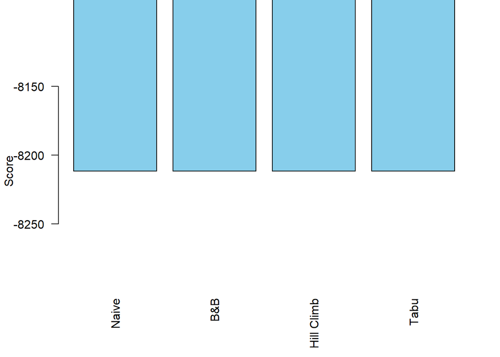

```r
# Automatic ylim with 10% extra on top
ylim_range <- range(scores$Score, na.rm = TRUE)
ylim_margin <- ylim_range[2] + 0.1 * abs(ylim_range[2] - ylim_range[1])

# PLOT SCORES
barplot(
  height = scores$Score,
  names.arg = scores$Algorithm,
  las = 2,
  col = "skyblue",
  ylab = "Score",
  ylim = c(ylim_range[1], ylim_margin)
)
```

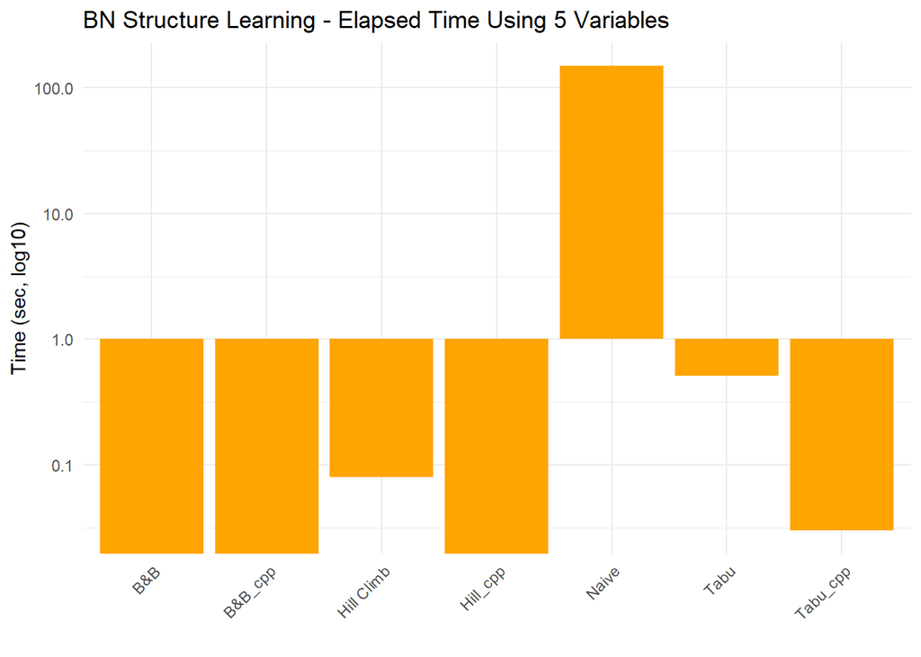

```r
library(ggplot2)
ggplot(times, aes(x = Algorithm, y = Time)) +
  geom_bar(stat = "identity", fill = "orange") +
  scale_y_log10() +
  theme_minimal() +
  theme(axis.text.x = element_text(angle = 45, hjust = 1)) +
  labs(
    title = "BN Structure Learning - Elapsed Time Using 5 Variables",
    y = "Time (sec, log10)",
    x = ""
  )
```

# 5. Higher number variable dataset analysis

To demonstrate the behavior of the branch and bound, and heuristic algorithms on a dataset with more variables, we applied B&B and Tabu Search to the full Boston Housing dataset ($p = 13$). As a result, the elapse running time of Branch and Bound are exceeding more than 20 minutes. Hence, we decided not to include the code of the B&B here. The example below highlights how the R and C++ of the Tabu Search implementations scale when the dimensionality increases.

```r
set.seed(5)

Boston_no_chas <- Boston[, !names(Boston) %in% "chas"]

time_hc_R_tit <- system.time(
  res_boston_r <- tabu_search_bn(Boston_no_chas, "gaussian", max_iter = 50, tabu_tenure = 10)
)
time_hc_R_tit
```

```
##    user  system elapsed
##   12.88    0.73   13.64
```

```r
time_boston_cpp_tit <- system.time(
  res_boston_cpp <- tabu_search_bn_cpp(Boston_no_chas, "gaussian", max_iter = 50, tabu_tenure = 10)
)
time_boston_cpp_tit
```

```
##    user  system elapsed
##    0.52    0.00    0.51
```

```r
speedup_ts_boston <- time_hc_R_tit["elapsed"] / time_boston_cpp_tit["elapsed"]
speedup_ts_boston
```

```
## elapsed
## 26.7451
```

```r
res_boston_r$adj <- set_adj_names(res_boston_r$adj, Boston_no_chas)
res_boston_r$adj
```

```
##         crim zn indus nox rm age dis rad tax ptratio black lstat medv
## crim       0  0     0   0  0   0   1   0   0       0     0     0    0
## zn         0  0     0   0  0   0   0   0   0       0     0     0    0
## indus      0  0     0   1  1   0   1   0   0       0     1     0    0
## nox        0  0     0   0  0   1   1   0   0       0     0     0    0
## rm         0  0     0   0  0   0   0   0   0       0     0     1    1
## age        0  1     0   0  0   0   0   0   0       0     0     1    0
## dis        0  1     0   0  0   1   0   0   0       0     0     0    0
## rad        1  0     1   1  0   0   0   0   1       1     1     1    0
## tax        0  1     1   0  0   0   1   0   0       0     0     0    1
## ptratio    0  1     0   1  0   0   1   0   0       0     0     1    0
## black      1  0     0   0  0   0   0   0   0       1     0     0    1
## lstat      0  0     0   0  0   0   0   0   0       0     0     0    0
## medv       1  1     0   1  0   1   1   0   0       1     0     1    0
```

```r
res_boston_r$score
```

```
## [1] -19918.14
```

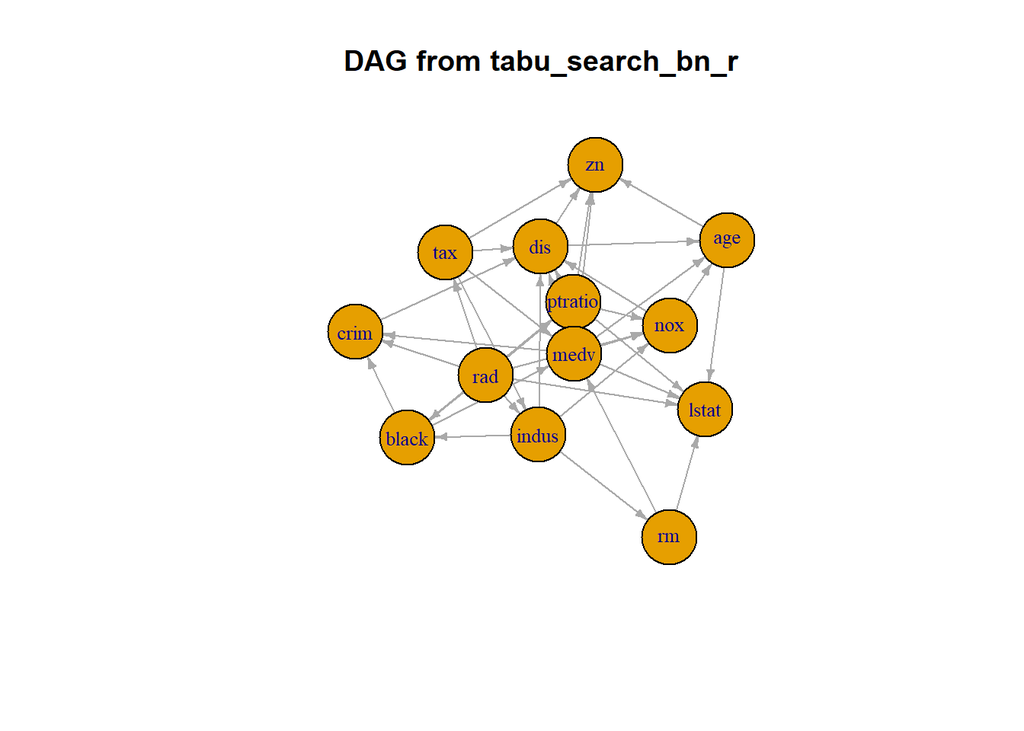

```r
library(igraph)
# adjacency matrix
A <- res_boston_r$adj

# convert to graph (directed)
g <- graph_from_adjacency_matrix(A, mode = "directed")

# plot
plot(
  g,
  layout = layout.fruchterman.reingold,
  vertex.size = 30,
  vertex.label.cex = 0.8,
  edge.arrow.size = 0.4,
  main = "DAG from tabu_search_bn_r"
)
```

```r
res_boston_cpp$adj <- set_adj_names(res_boston_cpp$adj, Boston_no_chas)
res_boston_cpp$adj
```

```
##         crim zn indus nox rm age dis rad tax ptratio black lstat medv
## crim       0  0     0   0  0   0   1   1   0       0     1     0    1
## zn         0  0     0   0  0   0   0   0   0       0     0     0    0
## indus      0  0     0   1  1   0   1   0   1       0     0     0    0
## nox        0  0     0   0  0   1   1   0   0       0     0     0    0
## rm         0  0     0   0  0   0   0   0   0       0     0     1    1
## age        0  1     0   0  0   0   0   0   0       0     0     1    0
## dis        0  1     0   0  0   1   0   0   0       0     0     0    0
## rad        0  0     1   1  0   0   0   0   1       1     1     1    1
## tax        0  1     0   0  0   0   1   0   0       0     0     0    1
## ptratio    0  1     0   1  0   0   1   0   0       0     0     1    0
## black      0  0     1   0  0   0   0   0   0       1     0     0    1
## lstat      0  0     0   0  0   0   0   0   0       0     0     0    0
## medv       0  1     0   1  0   1   1   0   0       1     0     1    0
```

```r
res_boston_cpp$score
```

```
## [1] -19922.94
```

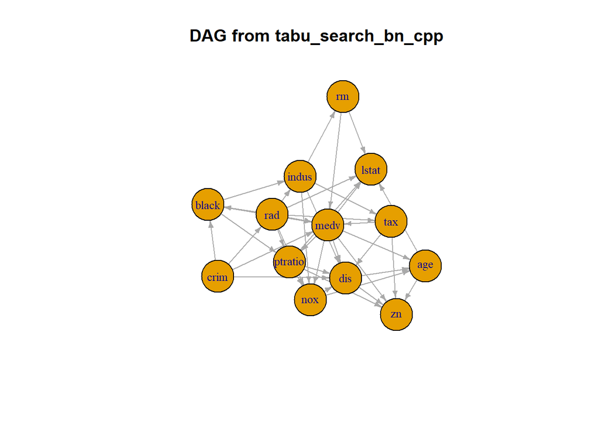

```r
library(igraph)

# adjacency matrix
A <- res_boston_cpp$adj

# convert to graph (directed)
g <- graph_from_adjacency_matrix(A, mode = "directed")

# plot
plot(
  g,
  layout = layout.fruchterman.reingold,
  vertex.size = 30,
  vertex.label.cex = 0.8,
  edge.arrow.size = 0.4,
  main = "DAG from tabu_search_bn_cpp"
)
```

```r
library(microbenchmark)

set.seed(123)

# Parameters
p_values <- 5:13
max_iter <- 50
tabu_tenure <- 10

# Store results
time_results <- data.frame(
  p = integer(),
  impl = character(),
  time_ms = numeric()
)

for (p in p_values) {

  X_sub <- Boston_no_chas[, 1:p]

  # ---- C++ version ----
  mb_cpp <- microbenchmark(
    tabu_search_bn_cpp(
      X_sub,
      distribution = "gaussian",
      max_iter = max_iter,
      tabu_tenure = tabu_tenure
    ),
    times = 5
  )

  time_results <- rbind(
    time_results,
    data.frame(
      p = p,
      impl = "C++",
      time_ms = median(mb_cpp$time) / 1e6
    )
  )

  # ---- R version ----
  mb_r <- microbenchmark(
    tabu_search_bn(
      X_sub,
      distribution = "gaussian",
      max_iter = max_iter,
      tabu_tenure = tabu_tenure
    ),
    times = 5
  )

  time_results <- rbind(
    time_results,
    data.frame(
      p = p,
      impl = "R",
      time_ms = median(mb_r$time) / 1e6
    )
  )

  cat("Done p =", p, "\n")
}
```

```
## Done p = 5
## Done p = 6
## Done p = 7
## Done p = 8
## Done p = 9
## Done p = 10
## Done p = 11
## Done p = 12
## Done p = 13
```

```r
print(time_results)
```

```
##     p impl    time_ms
## 1   5  C++    26.8353
## 2   5    R   547.4434
## 3   6  C++    46.0675
## 4   6    R  1043.2208
## 5   7  C++    74.5966
## 6   7    R  1641.9163
## 7   8  C++   112.9562
## 8   8    R  2576.6459
## 9   9  C++   163.0603
## 10  9    R  3853.8652
## 11 10  C++   230.1191
## 12 10    R  5452.3951
## 13 11  C++   324.2247
## 14 11    R  8019.2466
## 15 12  C++   403.8733
## 16 12    R 10502.0970
## 17 13  C++   520.4125
## 18 13    R 13640.3417
```

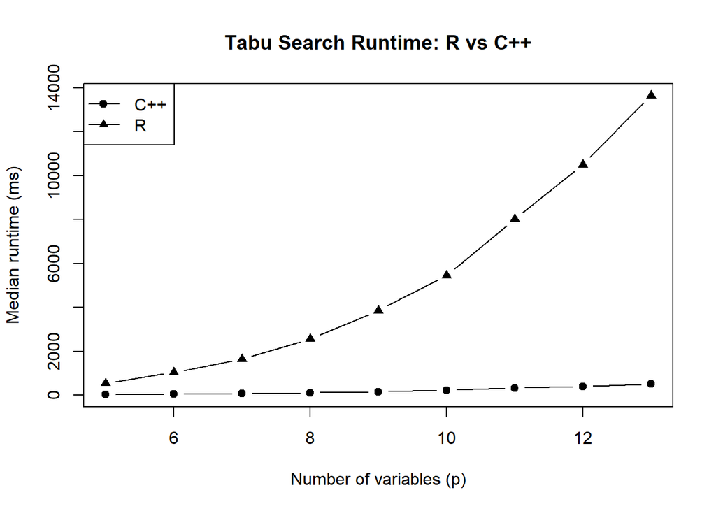

```r
plot(
  NULL,
  xlim = range(time_results$p),
  ylim = range(time_results$time_ms),
  xlab = "Number of variables (p)",
  ylab = "Median runtime (ms)",
  main = "Tabu Search Runtime: R vs C++"
)

lines(
  time_results$p[time_results$impl == "C++"],
  time_results$time_ms[time_results$impl == "C++"],
  type = "b",
  pch = 19
)

lines(
  time_results$p[time_results$impl == "R"],
  time_results$time_ms[time_results$impl == "R"],
  type = "b",
  pch = 17
)

legend(
  "topleft",
  legend = c("C++", "R"),
  pch = c(19, 17),
  lty = 1
)
```

## 5.1 Runtime Comparison

Tabu Search was run using:

- `distribution = "gaussian"`
- `max_iter = 50`

This reflects the computational advantage of compiled code when evaluating many candidate graphs.

## 5.2 Learned Structures

Both R and C++ implementations return valid DAGs. The adjacency matrices differ, but the BIC scores are similar, which is expected because:

- heuristic search may follow different paths,
- tabu lists introduce non-deterministic behavior,
- multiple DAGs can achieve the same score (Markov equivalence).

Overall, Tabu Search handles real data with higher dimensionality. Also, the C++ version provides a major runtime improvement. Different DAGs with similar scores are normal and acceptable in heuristic structure learning. This illustration confirms that the M2BayesNet package works efficiently on real, moderately sized continuous datasets.

# 6. Conclusion

However, as the dimensionality increases, the computational burden on B&B grows rapidly. For larger variable sets, heuristic algorithms become significantly faster and more practical. Although these heuristics do not guarantee convergence to the global optimum, they offer competitive solutions within a fraction of the time, making them suitable for high-dimensional or real-time applications.

Overall, the choice of algorithm depends on the problem size and the need for optimality: use B&B when exact global solutions are required and the variable set is small; use heuristics when scalability and speed are the priority, accepting a potential trade-off in optimality.